# Analysis of Cycling Data

We are provided with four files containing recordings of cycling activities that include GPS location data as well as some measurements related to cycling performace like heart rate and power. The goal is to perform some exploration and analysis of this data.

The data represents four races. Two are time trials where the rider rides alone on a set course. Two are road races where the rider rides with a peleton. All were held on the same course but the road races include two laps where the time trials include just one.

Questions to explore with the data:

- What is the overall distance travelled for each of the rides? What are the average speeds etc. Provide a summary for each ride.
- Compare the range of speeds for each ride, are time trials faster than road races?
- Compare the speeds achieved in the two time trials (three years apart). As well as looking at the averages, can you see where in the ride one or the other is faster.
- From the elevation_gain field you can see whether the rider is *climbing* , *descending* or on the *flat*. Use this to calculate the average speeds in those three cases (climbing, flat or descending). Note that *flat* might not be zero elevation_gain but might allow for slight climbs and falls.

For time varying data like this it is often useful to *smooth* the data using eg. a [rolling mean](https://pandas.pydata.org/pandas-docs/version/0.17.0/generated/pandas.rolling_mean.html). You might want to experiment with smoothing in some of your analysis (not required but may be of interest).

## Description of Fields

- *index* is a datetime showing the time that the observation was made (I wasn't riding at night, this is converted to UTC)
- **latitude, longitude, elevation** from the GPS, the position of the rider at each timepoint, elevation in m
- **temperature** the current ambient temperature in degrees celcius
- **power** the power being generated by the rider in Watts
- **cadence** the rotational speed of the pedals in revolutions per minute
- **hr** heart rate in beats per minute
- **elevation_gain** the change in elevation in m between two observations
- **distance** distance travelled between observations in km
- **speed** speed measured in km/h

You are provided with code in gpxutils.py to read the GPX XML format files that are exported by cycling computers and applications. The sample files were exported from [Strava](https://strava.com/) and represent four races by Steve Cassidy.

## 1.1 Import Libraries and Read in Data Set

```python
import pandas as pd
import numpy as np
from gpxutils import parse_gpx
import matplotlib.pyplot as plt
from datetime import timedelta
import statsmodels.api as sm
import statsmodels.formula.api as smf
from statsmodels.stats.anova import anova_lm
import statsmodels.stats.multicomp as multi
from scipy import stats
%matplotlib inline
```

```python
# read the four data files
rr_2016 = parse_gpx('files/Calga_RR_2016.gpx')
tt_2016 = parse_gpx('files/Calga_TT_2016.gpx')
rr_2019 = parse_gpx('files/Calga_RR_2019.gpx')
tt_2019 = parse_gpx('files/Calga_TT_2019.gpx')
```

## 1.2 Preliminary Investigation

```python
rr_2016.head()
```

|  | latitude | longitude | elevation | temperature | power | cadence | hr | distance | elevation_gain | speed | timedelta |
| --- | --- | --- | --- | --- | --- | --- | --- | --- | --- | --- | --- |
| 2016-05-14 04:02:41+00:00 | -33.415561 | 151.222303 | 208.6 | 29.0 | 0.0 | 40.0 | 102.0 | 0.000000 | 0.0 | 0.000000 | NaN |
| 2016-05-14 04:02:42+00:00 | -33.415534 | 151.222289 | 208.6 | 29.0 | 0.0 | 40.0 | 102.0 | 0.003271 | 0.0 | 11.777020 | 1.0 |
| 2016-05-14 04:02:46+00:00 | -33.415398 | 151.222180 | 208.6 | 29.0 | 0.0 | 40.0 | 103.0 | 0.018194 | 0.0 | 16.375033 | 4.0 |
| 2016-05-14 04:02:49+00:00 | -33.415264 | 151.222077 | 208.6 | 29.0 | 0.0 | 55.0 | 106.0 | 0.017703 | 0.0 | 21.243901 | 3.0 |
| 2016-05-14 04:02:51+00:00 | -33.415160 | 151.222013 | 208.6 | 29.0 | 0.0 | 61.0 | 109.0 | 0.013001 | 0.0 | 23.401217 | 2.0 |

```python
rr_2019.head()
```

|  | latitude | longitude | elevation | temperature | power | cadence | hr | distance | elevation_gain | speed | timedelta |
| --- | --- | --- | --- | --- | --- | --- | --- | --- | --- | --- | --- |
| 2019-06-22 22:33:45+00:00 | -33.416592 | 151.222853 | 215.0 | 0.0 | 0.0 | 58.0 | 71.0 | 0.000000 | 0.0 | 0.000000 | NaN |
| 2019-06-22 22:33:46+00:00 | -33.416629 | 151.222877 | 215.0 | 0.0 | 147.0 | 58.0 | 71.0 | 0.004679 | 0.0 | 16.842677 | 1.0 |
| 2019-06-22 22:33:47+00:00 | -33.416677 | 151.222905 | 214.8 | 0.0 | 97.0 | 60.0 | 71.0 | 0.005936 | -0.2 | 21.371074 | 1.0 |
| 2019-06-22 22:33:48+00:00 | -33.416730 | 151.222937 | 214.8 | 0.0 | 74.0 | 61.0 | 71.0 | 0.006599 | 0.0 | 23.757913 | 1.0 |
| 2019-06-22 22:33:49+00:00 | -33.416783 | 151.222972 | 214.8 | 0.0 | 136.0 | 62.0 | 71.0 | 0.006729 | 0.0 | 24.225566 | 1.0 |

```python
tt_2016.head()
```

|  | latitude | longitude | elevation | temperature | power | cadence | hr | distance | elevation_gain | speed | timedelta |
| --- | --- | --- | --- | --- | --- | --- | --- | --- | --- | --- | --- |
| 2016-07-02 23:05:30+00:00 | -33.415971 | 151.222016 | 111.8 | 12.0 | 0.0 | 58.0 | 108.0 | 0.000000 | 0.0 | 0.000000 | NaN |
| 2016-07-02 23:05:32+00:00 | -33.416026 | 151.222008 | 111.8 | 12.0 | 0.0 | 58.0 | 105.0 | 0.006161 | 0.0 | 11.089134 | 2.0 |
| 2016-07-02 23:05:38+00:00 | -33.416034 | 151.222023 | 111.8 | 12.0 | 0.0 | 58.0 | 105.0 | 0.001652 | 0.0 | 0.991282 | 6.0 |
| 2016-07-02 23:06:01+00:00 | -33.416041 | 151.222038 | 111.8 | 13.0 | 0.0 | 58.0 | 100.0 | 0.001595 | 0.0 | 0.249655 | 23.0 |
| 2016-07-02 23:06:02+00:00 | -33.416048 | 151.222053 | 111.8 | 13.0 | 0.0 | 65.0 | 101.0 | 0.001595 | 0.0 | 5.742071 | 1.0 |

```python
tt_2019.head(10)
```

|  | latitude | longitude | elevation | temperature | power | cadence | hr | distance | elevation_gain | speed | timedelta |
| --- | --- | --- | --- | --- | --- | --- | --- | --- | --- | --- | --- |
| 2019-06-01 22:54:55+00:00 | -33.415798 | 151.222060 | 219.4 | 13.0 | 0.0 | 0.0 | 88.0 | 0.000000 | 0.0 | 0.000000 | NaN |
| 2019-06-01 22:54:56+00:00 | -33.415782 | 151.222051 | 219.4 | 13.0 | 0.0 | 0.0 | 88.0 | 0.001965 | 0.0 | 7.075656 | 1.0 |
| 2019-06-01 22:54:57+00:00 | -33.415767 | 151.222041 | 219.4 | 13.0 | 0.0 | 0.0 | 88.0 | 0.001909 | 0.0 | 6.871582 | 1.0 |
| 2019-06-01 22:54:58+00:00 | -33.415751 | 151.222032 | 219.4 | 13.0 | 0.0 | 0.0 | 89.0 | 0.001965 | 0.0 | 7.075656 | 1.0 |
| 2019-06-01 22:54:59+00:00 | -33.415735 | 151.222022 | 219.4 | 13.0 | 0.0 | 0.0 | 89.0 | 0.002007 | 0.0 | 7.223997 | 1.0 |
| 2019-06-01 22:55:00+00:00 | -33.415719 | 151.222013 | 219.4 | 13.0 | 0.0 | 0.0 | 89.0 | 0.001965 | 0.0 | 7.075657 | 1.0 |
| 2019-06-01 22:55:01+00:00 | -33.415704 | 151.222003 | 219.4 | 13.0 | 0.0 | 0.0 | 90.0 | 0.001909 | 0.0 | 6.871583 | 1.0 |
| 2019-06-01 22:55:02+00:00 | -33.415688 | 151.221994 | 219.2 | 13.0 | 0.0 | 0.0 | 91.0 | 0.001965 | -0.2 | 7.075657 | 1.0 |
| 2019-06-01 22:55:03+00:00 | -33.415672 | 151.221984 | 219.2 | 13.0 | 0.0 | 0.0 | 92.0 | 0.002007 | 0.0 | 7.223998 | 1.0 |
| 2019-06-01 22:55:04+00:00 | -33.415656 | 151.221975 | 219.4 | 13.0 | 0.0 | 5.0 | 93.0 | 0.001965 | 0.2 | 7.075658 | 1.0 |

### Data Summary (Raw Data)

```python
## Summary Labels
raceType = ['Road Race 2016','Road Race 2019','Time Trial 2016', 'Time Trial 2019']
#Total distance in km
Distance = pd.Series([sum(rr_2016['distance']),sum(rr_2019['distance']),sum(tt_2016['distance']),sum(tt_2019['distance'])], index = raceType)
#Total time in HH:MM:SS
Time = pd.Series([str(timedelta(seconds = rr_2016['timedelta'].sum())),str(timedelta(seconds = rr_2019['timedelta'].sum())),str(timedelta(seconds = tt_2016['timedelta'].sum())),str(timedelta(seconds = tt_2019['timedelta'].sum()))], index = raceType)
#Total m of climbing
Total_Climb = pd.Series([sum(rr_2016[rr_2016['elevation_gain'] > 0]['elevation_gain']),sum(rr_2019[rr_2019['elevation_gain'] > 0]['elevation_gain']),sum(tt_2016[tt_2016['elevation_gain'] > 0]['elevation_gain']),sum(tt_2019[tt_2019['elevation_gain'] > 0]['elevation_gain'])], index = raceType)
#Max and min elevation in m
Max_Elevation = pd.Series([max(rr_2016['elevation']),max(rr_2019['elevation']),max(tt_2016['elevation']),max(tt_2019['elevation'])], index = raceType)
Min_Elevation = pd.Series([min(rr_2016['elevation']),min(rr_2019['elevation']),min(tt_2016['elevation']),min(tt_2019['elevation'])], index = raceType)
#Average and Max power in watts
Avg_Watts = pd.Series([rr_2016['power'].mean(),rr_2019['power'].mean(),tt_2016['power'].mean(),tt_2019['power'].mean()], index = raceType)
Max_Watts = pd.Series([max(rr_2016['power']),max(rr_2019['power']),max(tt_2016['power']),max(tt_2019['power'])], index = raceType)
#Average and Max speed in km/h
Avg_Speed = pd.Series([rr_2016['speed'].mean(),rr_2019['speed'].mean(),tt_2016['speed'].mean(),tt_2019['speed'].mean()], index = raceType)
Max_Speed = pd.Series([max(rr_2016['speed']),max(rr_2019['speed']),max(tt_2016['speed']),max(tt_2019['speed'])], index = raceType)
#Average, Max and Min heart rate in BPM
Avg_HR = pd.Series([rr_2016['hr'].mean(),rr_2019['hr'].mean(),tt_2016['hr'].mean(),tt_2019['hr'].mean()], index = raceType)
Max_HR = pd.Series([max(rr_2016['hr']),max(rr_2019['hr']),max(tt_2016['hr']),max(tt_2019['hr'])], index = raceType)
Min_HR = pd.Series([min(rr_2016['hr']),min(rr_2019['hr']),min(tt_2016['hr']),min(tt_2019['hr'])], index = raceType)
#Average and Max cadence in RPM
Avg_Cadence = pd.Series([rr_2016['cadence'].mean(),rr_2019['cadence'].mean(),tt_2016['cadence'].mean(),tt_2019['cadence'].mean()], index = raceType)
Max_Cadence = pd.Series([max(rr_2016['cadence']),max(rr_2019['cadence']),max(tt_2016['cadence']),max(tt_2019['cadence'])], index = raceType)
#Summary Statistics data frame
rideSummary = pd.DataFrame({'Distance': Distance, 'Total Time': Time, 'Total Climbing':Total_Climb, 'Max Elv': Max_Elevation, 'Min Elv': Min_Elevation, 'Avg. Watts':Avg_Watts,'Max Watts': Max_Watts, 'Avg. Speed':Avg_Speed, 'Max Speed':Max_Speed, 'Avg. HR':Avg_HR, 'Max HR': Max_HR, 'Min HR': Min_HR, 'Avg. Cadence':Avg_Cadence, 'Max Cadence': Max_Cadence }, index = raceType)
rideSummary.round(2)
```

|  | Distance | Total Time | Total Climbing | Max Elv | Min Elv | Avg. Watts | Max Watts | Avg. Speed | Max Speed | Avg. HR | Max HR | Min HR | Avg. Cadence | Max Cadence |
| --- | --- | --- | --- | --- | --- | --- | --- | --- | --- | --- | --- | --- | --- | --- |
| Road Race 2016 | 49.05 | 1:26:40 | 515.0 | 295.8 | 176.0 | 0.00 | 0.0 | 34.93 | 92.75 | 158.39 | 205.0 | 102.0 | 65.99 | 117.0 |
| Road Race 2019 | 51.79 | 1:31:42 | 687.2 | 310.4 | 185.2 | 213.62 | 785.0 | 33.88 | 70.37 | 139.00 | 170.0 | 71.0 | 70.00 | 120.0 |
| Time Trial 2016 | 24.80 | 0:45:47 | 288.6 | 202.6 | 85.0 | 0.00 | 0.0 | 33.53 | 162.51 | 170.94 | 251.0 | 100.0 | 83.28 | 118.0 |
| Time Trial 2019 | 24.38 | 0:44:14 | 288.8 | 312.2 | 195.8 | 257.57 | 522.0 | 33.06 | 63.30 | 152.74 | 166.0 | 88.0 | 89.98 | 111.0 |

## 1.3 Data Cleaning

```python
mTime = rr_2016['timedelta'].mean()
print(f'Number of observations for road race 2016 MA window: {np.ceil(10/mTime)}')
```

```
Number of observations for road race 2016 MA window: 6.0
```

```python
mTime = rr_2019['timedelta'].mean()
print(f'Number of observations for road race 2019 MA window: {np.ceil(10/mTime)}')
```

```
Number of observations for road race 2019 MA window: 10.0
```

```python
mTime = tt_2016['timedelta'].mean()
print(f'Number of observations for time trial 2016 MA window: {np.ceil(10/mTime)}')
```

```
Number of observations for time trial 2016 MA window: 6.0
```

```python
mTime = tt_2019['timedelta'].mean()
print(f'Number of observations for time trial 2019 MA window: {np.ceil(10/mTime)}')
```

```
Number of observations for time trial 2019 MA window: 10.0
```

```python
#reset heart rate values > 185 to 185
rr_2016['hr'].mask(rr_2016['hr']>185,other = 185, inplace = True)

#calculate smoothed values and index elevation to min elevation
rr16_elv_idx = rr_2016['elevation'] - rr_2016['elevation'].min()
rr16_pwr_Rm = rr_2016['power'].rolling(6).mean()
rr16_cad_Rm = rr_2016['cadence'].rolling(6).mean()
rr16_hr_Rm = rr_2016['hr'].rolling(6).mean()
rr16_spd_Rm = rr_2016['speed'].rolling(6).mean()

#create new data frame with smoothed values and indexed elevation
rr_2016C = pd.DataFrame({'latitude': rr_2016['latitude'], 'longitude': rr_2016['longitude'],
                         'elevation_idx': rr16_elv_idx, 'power': rr16_pwr_Rm, 'cadence': rr16_cad_Rm,
                         'hr': rr16_hr_Rm, 'distance': rr_2016['distance'],
                         'elevation_gain': rr_2016['elevation_gain'], 'speed':rr16_spd_Rm,
                         'timedelta': rr_2016['timedelta']
                        })
rr_2016C.tail()
```

|  | latitude | longitude | elevation_idx | power | cadence | hr | distance | elevation_gain | speed | timedelta |
| --- | --- | --- | --- | --- | --- | --- | --- | --- | --- | --- |
| 2016-05-14 05:29:16+00:00 | -33.416432 | 151.222722 | 22.4 | 0.0 | 0.0 | 181.833333 | 0.008624 | 0.0 | 34.583471 | 1.0 |
| 2016-05-14 05:29:17+00:00 | -33.416497 | 151.222764 | 22.4 | 0.0 | 0.0 | 179.000000 | 0.008212 | 0.0 | 33.634640 | 1.0 |
| 2016-05-14 05:29:18+00:00 | -33.416563 | 151.222807 | 22.4 | 0.0 | 0.0 | 175.500000 | 0.008354 | 0.0 | 32.064856 | 1.0 |
| 2016-05-14 05:29:19+00:00 | -33.416627 | 151.222852 | 22.4 | 0.0 | 0.0 | 171.500000 | 0.008252 | 0.0 | 31.140375 | 1.0 |
| 2016-05-14 05:29:21+00:00 | -33.416753 | 151.222934 | 22.0 | 0.0 | 0.0 | 167.000000 | 0.015944 | -0.4 | 30.282679 | 2.0 |

```python
#calculate smoothed values and index elevation to min elevation
rr19_elv_idx = rr_2019['elevation'] - rr_2019['elevation'].min()
rr19_pwr_Rm = rr_2019['power'].rolling(10).mean()
rr19_cad_Rm = rr_2019['cadence'].rolling(10).mean()
rr19_hr_Rm = rr_2019['hr'].rolling(10).mean()
rr19_spd_Rm = rr_2019['speed'].rolling(10).mean()

#create new data frame with smoothed values and indexed elevation
rr_2019C = pd.DataFrame({'latitude': rr_2019['latitude'], 'longitude': rr_2019['longitude'],
                         'elevation_idx': rr19_elv_idx, 'power': rr19_pwr_Rm, 'cadence': rr19_cad_Rm,
                         'hr': rr19_hr_Rm, 'distance': rr_2019['distance'],
                         'elevation_gain': rr_2019['elevation_gain'], 'speed':rr19_spd_Rm,
                         'timedelta': rr_2019['timedelta']
                        })
rr_2019C.tail()
```

|  | latitude | longitude | elevation_idx | power | cadence | hr | distance | elevation_gain | speed | timedelta |
| --- | --- | --- | --- | --- | --- | --- | --- | --- | --- | --- |
| 2019-06-23 00:05:23+00:00 | -33.415728 | 151.222289 | 31.4 | 209.0 | 77.0 | 153.0 | 0.010218 | -0.2 | 38.510606 | 1.0 |
| 2019-06-23 00:05:24+00:00 | -33.415808 | 151.222340 | 31.4 | 183.4 | 68.6 | 153.0 | 0.010077 | 0.0 | 38.235780 | 1.0 |
| 2019-06-23 00:05:25+00:00 | -33.415885 | 151.222391 | 31.4 | 155.8 | 59.2 | 152.9 | 0.009783 | 0.0 | 37.835513 | 1.0 |
| 2019-06-23 00:05:26+00:00 | -33.415962 | 151.222440 | 31.4 | 128.7 | 49.8 | 152.8 | 0.009695 | 0.0 | 37.438904 | 1.0 |
| 2019-06-23 00:05:27+00:00 | -33.416037 | 151.222489 | 31.2 | 102.1 | 40.3 | 152.6 | 0.009499 | -0.2 | 36.940327 | 1.0 |

```python
#drop the intial 4 observations, speed = 0 (assummed record of waiting at the start)
tt_2016 = tt_2016.iloc[4:]

#reset heart rate values > 185 to 185
tt_2016['hr'].mask(tt_2016['hr']>185,other = 185, inplace = True)

#calculate smoothed values and index elevation to min elevation
tt16_elv_idx = tt_2016['elevation'] - tt_2016['elevation'].min()
tt16_pwr_Rm = tt_2016['power'].rolling(6).mean()
tt16_cad_Rm = tt_2016['cadence'].rolling(6).mean()
tt16_hr_Rm = tt_2016['hr'].rolling(6).mean()
tt16_spd_Rm = tt_2016['speed'].rolling(6).mean()

#create new data frame with smoothed values and indexed elevation
tt_2016C = pd.DataFrame({'latitude': tt_2016['latitude'], 'longitude': tt_2016['longitude'],
                         'elevation_idx': tt16_elv_idx, 'power': tt16_pwr_Rm, 'cadence': tt16_cad_Rm,
                         'hr': tt16_hr_Rm, 'distance': tt_2016['distance'],
                         'elevation_gain': tt_2016['elevation_gain'], 'speed':tt16_spd_Rm,
                         'timedelta': tt_2016['timedelta']
                        })
tt_2016C.tail()
```

|  | latitude | longitude | elevation_idx | power | cadence | hr | distance | elevation_gain | speed | timedelta |
| --- | --- | --- | --- | --- | --- | --- | --- | --- | --- | --- |
| 2016-07-02 23:50:39+00:00 | -33.415476 | 151.221628 | 31.0 | 0.0 | 99.666667 | 162.000000 | 0.024989 | 0.0 | 44.866798 | 2.0 |
| 2016-07-02 23:50:41+00:00 | -33.415667 | 151.221757 | 30.4 | 0.0 | 99.500000 | 162.333333 | 0.024381 | -0.6 | 44.577990 | 2.0 |
| 2016-07-02 23:50:45+00:00 | -33.416048 | 151.222013 | 30.4 | 0.0 | 82.833333 | 162.333333 | 0.048573 | 0.0 | 44.424255 | 4.0 |
| 2016-07-02 23:51:16+00:00 | -33.418333 | 151.223478 | 23.0 | 0.0 | 77.000000 | 159.166667 | 0.288175 | -7.4 | 42.503752 | 31.0 |
| 2016-07-02 23:51:17+00:00 | -33.418368 | 151.223494 | 23.0 | 0.0 | 71.166667 | 156.000000 | 0.004166 | 0.0 | 37.590673 | 1.0 |

```python
#drop the intial 10 observations, power = 0 , cadence = 0 (assummed record of waiting at the start)
tt_2019 = tt_2019.iloc[10:]

#calculate smoothed values and index elevation to min elevation
tt19_elv_idx = tt_2019['elevation'] - tt_2019['elevation'].min()
tt19_pwr_Rm = tt_2019['power'].rolling(10).mean()
tt19_cad_Rm = tt_2019['cadence'].rolling(10).mean()
tt19_hr_Rm = tt_2019['hr'].rolling(10).mean()
tt19_spd_Rm = tt_2019['speed'].rolling(10).mean()

#create new data frame with smoothed values and indexed elevation
tt_2019C = pd.DataFrame({'latitude': tt_2019['latitude'], 'longitude': tt_2019['longitude'],
                         'elevation_idx': tt19_elv_idx, 'power': tt19_pwr_Rm, 'cadence': tt19_cad_Rm,
                         'hr': tt19_hr_Rm, 'distance': tt_2019['distance'],
                         'elevation_gain': tt_2019['elevation_gain'], 'speed':tt19_spd_Rm,
                         'timedelta': tt_2019['timedelta']
                        })
tt_2019C.tail()
```

|  | latitude | longitude | elevation_idx | power | cadence | hr | distance | elevation_gain | speed | timedelta |
| --- | --- | --- | --- | --- | --- | --- | --- | --- | --- | --- |
| 2019-06-01 23:39:05+00:00 | -33.415270 | 151.221994 | 25.0 | 314.6 | 100.5 | 166.0 | 0.012323 | -0.2 | 44.010693 | 1.0 |
| 2019-06-01 23:39:06+00:00 | -33.415367 | 151.222056 | 25.0 | 323.2 | 100.6 | 166.0 | 0.012225 | 0.0 | 44.524902 | 1.0 |
| 2019-06-01 23:39:07+00:00 | -33.415462 | 151.222122 | 24.8 | 319.2 | 100.7 | 166.0 | 0.012211 | -0.2 | 44.550982 | 1.0 |
| 2019-06-01 23:39:08+00:00 | -33.415555 | 151.222189 | 24.6 | 307.4 | 100.6 | 166.0 | 0.012067 | -0.2 | 43.955316 | 1.0 |
| 2019-06-01 23:39:09+00:00 | -33.415648 | 151.222255 | 24.6 | 290.1 | 97.8 | 166.0 | 0.012019 | 0.0 | 43.861411 | 1.0 |

## 1.4 Data Summary of rides

### *What is the overall distance travelled for each of the rides? What are the average speeds etc. Provide a summary for each ride.*

```python
## Summary Labels
raceType = ['Road Race 2016','Road Race 2019','Time Trial 2016', 'Time Trial 2019']
#Total distance in km
Distance = pd.Series([sum(rr_2016C['distance']),sum(rr_2019C['distance']),sum(tt_2016C['distance']),sum(tt_2019C['distance'])], index = raceType)
#Total time in HH:MM:SS
Time = pd.Series([str(timedelta(seconds = rr_2016C['timedelta'].sum())),str(timedelta(seconds = rr_2019C['timedelta'].sum())),str(timedelta(seconds = tt_2016C['timedelta'].sum())),str(timedelta(seconds = tt_2019C['timedelta'].sum()))], index = raceType)
#Total m of climbing
Total_Climb = pd.Series([sum(rr_2016C[rr_2016C['elevation_gain'] > 0]['elevation_gain']),sum(rr_2019C[rr_2019C['elevation_gain'] > 0]['elevation_gain']),sum(tt_2016C[tt_2016C['elevation_gain'] > 0]['elevation_gain']),sum(tt_2019C[tt_2019C['elevation_gain'] > 0]['elevation_gain'])], index = raceType)
#Max and min elevation in m
Max_Elevation = pd.Series([max(rr_2016C['elevation_idx']),max(rr_2019C['elevation_idx']),max(tt_2016C['elevation_idx']),max(tt_2019C['elevation_idx'])], index = raceType)
Min_Elevation = pd.Series([min(rr_2016C['elevation_idx']),min(rr_2019C['elevation_idx']),min(tt_2016C['elevation_idx']),min(tt_2019C['elevation_idx'])], index = raceType)
#Average and Max power in watts
Avg_Watts = pd.Series([rr_2016C['power'].mean(),rr_2019C['power'].mean(),tt_2016C['power'].mean(),tt_2019C['power'].mean()], index = raceType)
Max_Watts = pd.Series([rr_2016C['power'].max(),rr_2019C['power'].max(), tt_2016C['power'].max(), tt_2019C['power'].max()], index = raceType)
#Average and Max speed in km/h
Avg_Speed = pd.Series([rr_2016C['speed'].mean(),rr_2019C['speed'].mean(),tt_2016C['speed'].mean(),tt_2019C['speed'].mean()], index = raceType)
Max_Speed = pd.Series([rr_2016C['speed'].max(), rr_2019C['speed'].max(), tt_2016C['speed'].max(), tt_2019C['speed'].max()], index = raceType)
#Average, Max and Min heart rate in BPM
Avg_HR = pd.Series([rr_2016C['hr'].mean(),rr_2019C['hr'].mean(),tt_2016C['hr'].mean(),tt_2019C['hr'].mean()], index = raceType)
Max_HR = pd.Series([rr_2016C['hr'].max(), rr_2019C['hr'].max(), tt_2016C['hr'].max(), tt_2019C['hr'].max()], index = raceType)
Min_HR = pd.Series([rr_2016C['hr'].min(), rr_2019C['hr'].min(), tt_2016C['hr'].min(), tt_2019C['hr'].min()], index = raceType)
#Average and Max cadence in RPM
Avg_Cadence = pd.Series([rr_2016C['cadence'].mean(),rr_2019C['cadence'].mean(),tt_2016C['cadence'].mean(),tt_2019C['cadence'].mean()], index = raceType)
Max_Cadence = pd.Series([rr_2016C['cadence'].max(),rr_2019C['cadence'].max(), tt_2016C['cadence'].max(), tt_2019C['cadence'].max()], index = raceType)
#Summary Statistics data frame
rideSummary = pd.DataFrame({'Distance': Distance, 'Total Time': Time, 'Total Climbing':Total_Climb, 'Max Elv': Max_Elevation, 'Min Elv': Min_Elevation, 'Avg. Watts':Avg_Watts,'Max Watts': Max_Watts, 'Avg. Speed':Avg_Speed, 'Max Speed':Max_Speed, 'Avg. HR':Avg_HR, 'Max HR': Max_HR, 'Min HR': Min_HR, 'Avg. Cadence':Avg_Cadence, 'Max Cadence': Max_Cadence }, index = raceType)
rideSummary.round(2)
```

|  | Distance | Total Time | Total Climbing | Max Elv | Min Elv | Avg. Watts | Max Watts | Avg. Speed | Max Speed | Avg. HR | Max HR | Min HR | Avg. Cadence | Max Cadence |
| --- | --- | --- | --- | --- | --- | --- | --- | --- | --- | --- | --- | --- | --- | --- |
| Road Race 2016 | 49.05 | 1:26:40 | 515.0 | 119.8 | 0.0 | 0.00 | 0.0 | 34.96 | 66.86 | 158.32 | 185.0 | 105.17 | 66.07 | 114.5 |
| Road Race 2019 | 51.79 | 1:31:42 | 687.2 | 125.2 | 0.0 | 213.86 | 667.9 | 33.89 | 68.62 | 139.04 | 169.2 | 71.00 | 70.06 | 111.0 |
| Time Trial 2016 | 24.79 | 0:45:16 | 288.6 | 117.6 | 0.0 | 0.00 | 0.0 | 33.64 | 64.50 | 166.00 | 185.0 | 110.00 | 83.39 | 114.0 |
| Time Trial 2019 | 24.36 | 0:44:05 | 288.6 | 116.4 | 0.0 | 258.27 | 436.1 | 33.17 | 61.89 | 153.05 | 166.0 | 102.50 | 90.36 | 107.2 |

The table above outlines a summary of each ride including the total distiance traveled and average speeds.

Below are a series of plots which summarise the rides graphically.

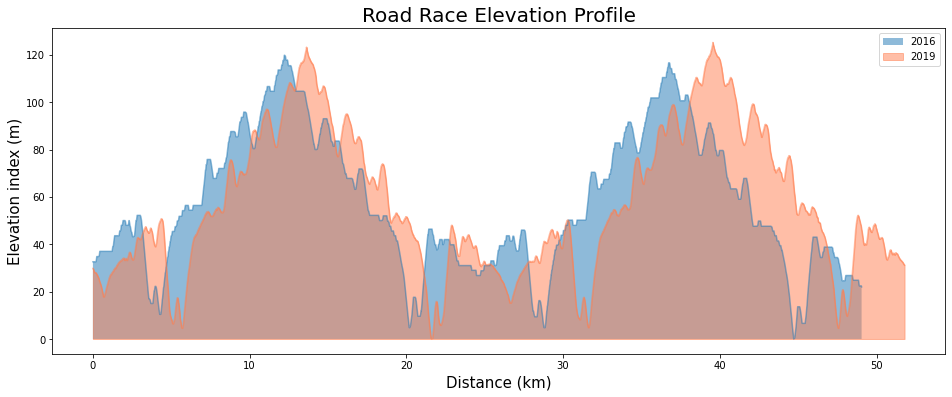

```python
plt.figure(figsize=(16,6))
plt.plot(rr_2016C['distance'].cumsum(),rr_2016C['elevation_idx'], alpha = 0.5)
plt.fill_between(rr_2016C['distance'].cumsum(),rr_2016C['elevation_idx'], alpha = 0.5, label = '2016')
plt.plot(rr_2019C['distance'].cumsum(),rr_2019C['elevation_idx'], alpha = 0.5, color = 'coral')
plt.fill_between(rr_2019C['distance'].cumsum(),rr_2019C['elevation_idx'], alpha = 0.5, label = '2019', color = 'coral')
plt.xlabel('Distance (km)', size=15)
plt.ylabel('Elevation index (m)', size=15)
plt.title("Road Race Elevation Profile", size = 20)
plt.legend()
plt.show()
```

The road race profiles do not align from what is assumed to be a discrpenacy in the measurements.

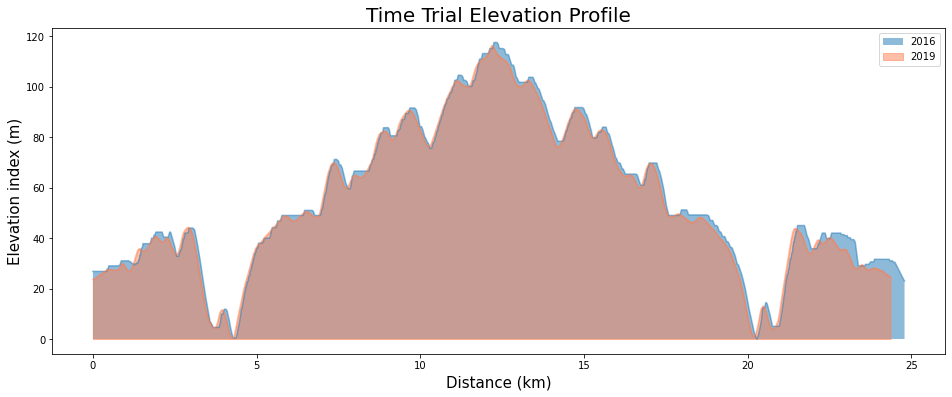

```python
plt.figure(figsize=(16,6))
plt.plot(tt_2016C['distance'].cumsum(),tt_2016C['elevation_idx'], alpha = 0.5)
plt.fill_between(tt_2016C['distance'].cumsum(),tt_2016C['elevation_idx'], alpha = 0.5, label = '2016')
plt.plot(tt_2019C['distance'].cumsum(),tt_2019C['elevation_idx'], alpha = 0.5, color = 'coral')
plt.fill_between(tt_2019C['distance'].cumsum(),tt_2019C['elevation_idx'], alpha = 0.5, label = '2019', color = 'coral')
plt.xlabel('Distance (km)', size=15)
plt.ylabel('Elevation index (m)', size=15)
plt.title("Time Trial Elevation Profile", size = 20)
plt.legend()
plt.show()
```

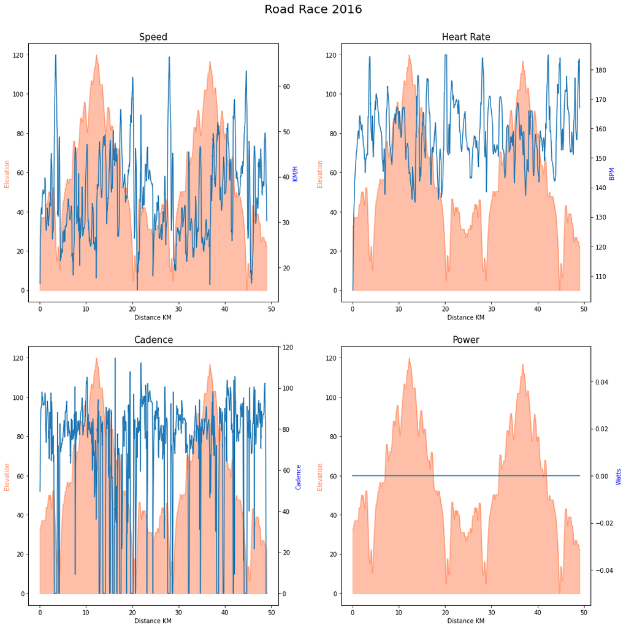

```python
fig, rr16Profile = plt.subplots(2,2,figsize=(15,15))
fig.suptitle('Road Race 2016', size = 20)

#Speed graph
ax2 = rr16Profile[0,0].twinx()
ax2.plot(rr_2016C['distance'].cumsum(),rr_2016C['speed'])
rr16Profile[0,0].plot(rr_2016C['distance'].cumsum(),rr_2016C['elevation_idx'], alpha = 0.5, color = 'coral')
rr16Profile[0,0].fill_between(rr_2016C['distance'].cumsum(),rr_2016C['elevation_idx'], alpha = 0.5, label = '2016', color = 'coral')
rr16Profile[0,0].set_ylabel('Elevation', color = 'coral')
ax2.set_ylabel('KM/H', color = 'blue')
rr16Profile[0,0].set_title('Speed', size = 15)

#heart rate graph
ax2 = rr16Profile[0,1].twinx()
ax2.plot(rr_2016C['distance'].cumsum(),rr_2016C['hr'])
rr16Profile[0,1].plot(rr_2016C['distance'].cumsum(),rr_2016C['elevation_idx'], alpha = 0.5, color = 'coral')
rr16Profile[0,1].fill_between(rr_2016C['distance'].cumsum(),rr_2016C['elevation_idx'], alpha = 0.5, label = '2016', color = 'coral')
rr16Profile[0,1].set_ylabel('Elevation', color = 'coral')
ax2.set_ylabel('BPM', color='blue')
rr16Profile[0,1].set_title('Heart Rate', size = 15)

#Cadence graph
ax2 = rr16Profile[1,0].twinx()
ax2.plot(rr_2016C['distance'].cumsum(),rr_2016C['cadence'])
rr16Profile[1,0].plot(rr_2016C['distance'].cumsum(),rr_2016C['elevation_idx'], alpha = 0.5, color = 'coral')
rr16Profile[1,0].fill_between(rr_2016C['distance'].cumsum(),rr_2016C['elevation_idx'], alpha = 0.5, label = '2016', color = 'coral')
rr16Profile[1,0].set_ylabel('Elevation', color = 'coral')
ax2.set_ylabel('Cadence', color = 'blue')
rr16Profile[1,0].set_title('Cadence', size = 15)

#power graph
ax2 = rr16Profile[1,1].twinx()
ax2.plot(rr_2016['distance'].cumsum(),rr_2016['power'])
rr16Profile[1,1].plot(rr_2016C['distance'].cumsum(),rr_2016C['elevation_idx'], alpha = 0.5, color = 'coral')
rr16Profile[1,1].fill_between(rr_2016C['distance'].cumsum(),rr_2016C['elevation_idx'], alpha = 0.5, label = '2016', color = 'coral')
rr16Profile[1,1].set_ylabel('Elevation', color = 'coral')
ax2.set_ylabel('Watts', color = 'blue')
rr16Profile[1,1].set_title('Power', size = 15)

for rr16Profile in rr16Profile.flat:
    rr16Profile.set(xlabel='Distance KM')

fig.tight_layout(pad = 2.5)
```

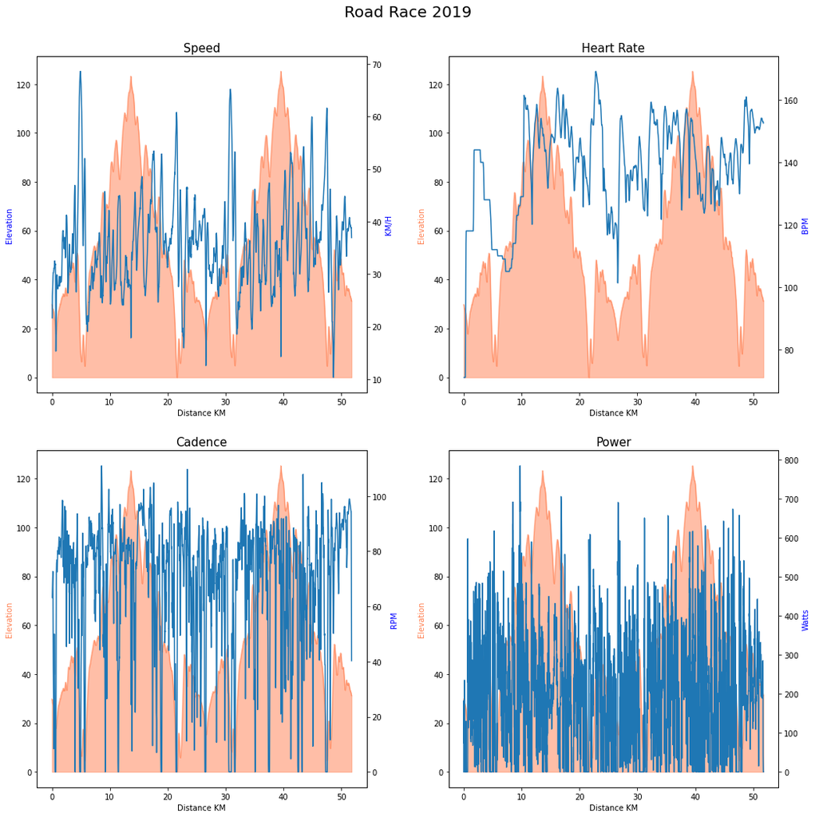

```python
fig, rr19Profile = plt.subplots(2,2,figsize=(15,15))
fig.suptitle('Road Race 2019', size = 20)

#Speed graph
ax2 = rr19Profile[0,0].twinx()
ax2.plot(rr_2019C['distance'].cumsum(),rr_2019C['speed'])
rr19Profile[0,0].plot(rr_2019C['distance'].cumsum(),rr_2019C['elevation_idx'], alpha = 0.5, color = 'coral')
rr19Profile[0,0].fill_between(rr_2019C['distance'].cumsum(),rr_2019C['elevation_idx'], alpha = 0.5, label = '2016', color = 'coral')
ax2.set_ylabel('KM/H', color = 'blue')
rr19Profile[0,0].set_ylabel('Elevation', color = 'blue')
rr19Profile[0,0].set_title('Speed', size = 15)

#heart rate graph
ax2 = rr19Profile[0,1].twinx()
ax2.plot(rr_2019C['distance'].cumsum(),rr_2019C['hr'])
rr19Profile[0,1].plot(rr_2019C['distance'].cumsum(),rr_2019C['elevation_idx'], alpha = 0.5, color = 'coral')
rr19Profile[0,1].fill_between(rr_2019C['distance'].cumsum(),rr_2019C['elevation_idx'], alpha = 0.5, label = '2016', color = 'coral')
ax2.set_ylabel('BPM', color = 'blue')
rr19Profile[0,1].set_ylabel('Elevation', color = 'coral')
rr19Profile[0,1].set_title('Heart Rate', size = 15)

#Cadence graph
ax2 = rr19Profile[1,0].twinx()
ax2.plot(rr_2019C['distance'].cumsum(),rr_2019C['cadence'])
rr19Profile[1,0].plot(rr_2019C['distance'].cumsum(),rr_2019C['elevation_idx'], alpha = 0.5, color = 'coral')
rr19Profile[1,0].fill_between(rr_2019C['distance'].cumsum(),rr_2019C['elevation_idx'], alpha = 0.5, label = '2016', color = 'coral')
ax2.set_ylabel('RPM', color = 'blue')
rr19Profile[1,0].set_ylabel('Elevation', color = 'coral')
rr19Profile[1,0].set_title('Cadence', size = 15)

#power graph
ax2 = rr19Profile[1,1].twinx()
ax2.plot(rr_2019['distance'].cumsum(),rr_2019['power'])
rr19Profile[1,1].plot(rr_2019C['distance'].cumsum(),rr_2019C['elevation_idx'], alpha = 0.5, color = 'coral')
rr19Profile[1,1].fill_between(rr_2019C['distance'].cumsum(),rr_2019C['elevation_idx'], alpha = 0.5, label = '2016', color = 'coral')
ax2.set_ylabel('Watts', color = 'blue')
rr19Profile[1,1].set_ylabel('Elevation', color = 'coral')
rr19Profile[1,1].set_title('Power', size = 15)

for rr19Profile in rr19Profile.flat:
    rr19Profile.set(xlabel='Distance KM')

fig.tight_layout(pad = 2.5)
```

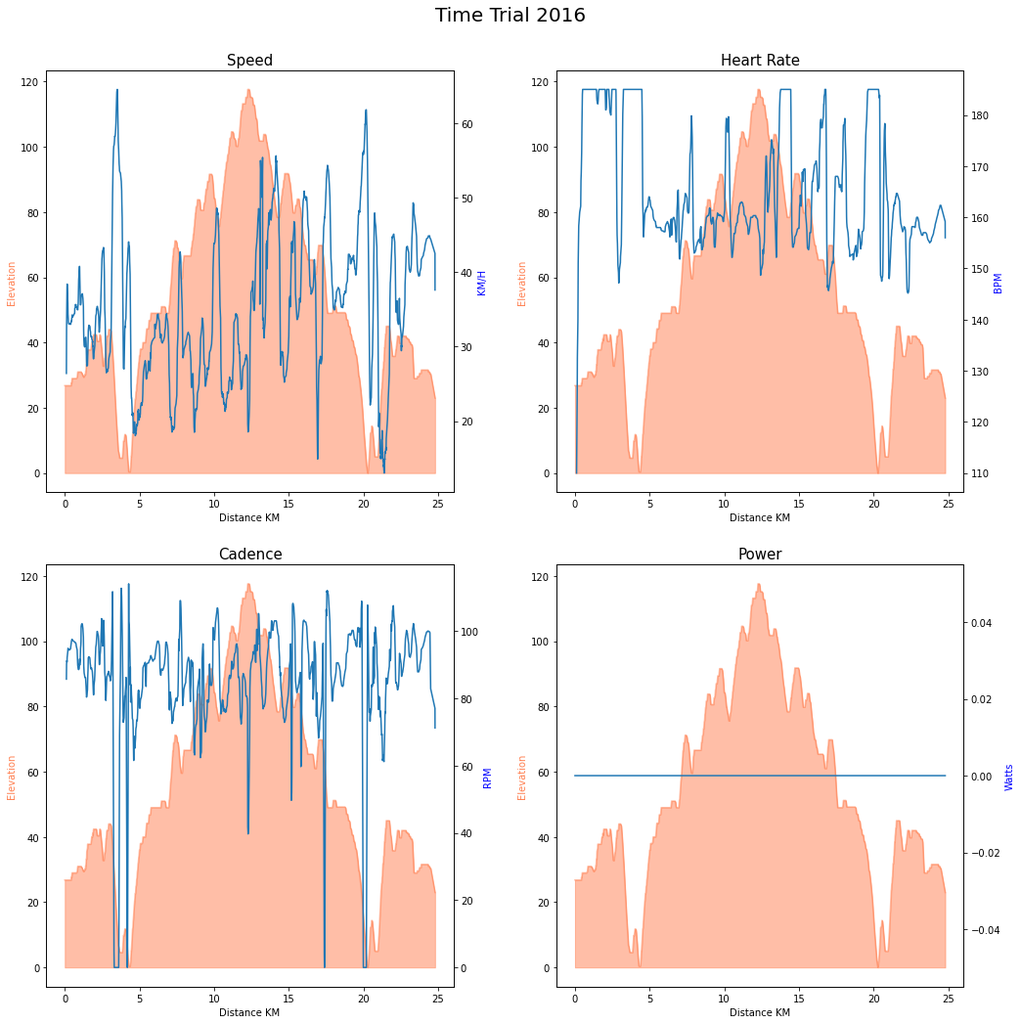

```python
fig, tt16Profile = plt.subplots(2,2,figsize=(15,15))
fig.suptitle('Time Trial 2016', size = 20)

#Speed graph
ax2 = tt16Profile[0,0].twinx()
ax2.plot(tt_2016C['distance'].cumsum(),tt_2016C['speed'])
tt16Profile[0,0].plot(tt_2016C['distance'].cumsum(),tt_2016C['elevation_idx'], alpha = 0.5, color = 'coral')
tt16Profile[0,0].fill_between(tt_2016C['distance'].cumsum(),tt_2016C['elevation_idx'], alpha = 0.5, label = '2016', color = 'coral')
ax2.set_ylabel('KM/H', color = 'blue')
tt16Profile[0,0].set_ylabel('Elevation', color = 'coral')
tt16Profile[0,0].set_title('Speed', size = 15)

#heart rate graph
ax2 = tt16Profile[0,1].twinx()
ax2.plot(tt_2016C['distance'].cumsum(),tt_2016C['hr'])
tt16Profile[0,1].plot(tt_2016C['distance'].cumsum(),tt_2016C['elevation_idx'], alpha = 0.5, color = 'coral')
tt16Profile[0,1].fill_between(tt_2016C['distance'].cumsum(),tt_2016C['elevation_idx'], alpha = 0.5, label = '2016', color = 'coral')
ax2.set_ylabel('BPM', color = 'blue')
tt16Profile[0,1].set_ylabel('Elevation', color = 'coral')
tt16Profile[0,1].set_title('Heart Rate', size = 15)

#Cadence graph
ax2 = tt16Profile[1,0].twinx()
ax2.plot(tt_2016C['distance'].cumsum(),tt_2016C['cadence'])
tt16Profile[1,0].plot(tt_2016C['distance'].cumsum(),tt_2016C['elevation_idx'], alpha = 0.5, color = 'coral')
tt16Profile[1,0].fill_between(tt_2016C['distance'].cumsum(),tt_2016C['elevation_idx'], alpha = 0.5, label = '2016', color = 'coral')
ax2.set_ylabel('RPM', color = 'blue')
tt16Profile[1,0].set_ylabel('Elevation', color = 'coral')
tt16Profile[1,0].set_title('Cadence', size = 15)

#power graph
ax2 = tt16Profile[1,1].twinx()
ax2.plot(tt_2016['distance'].cumsum(),tt_2016['power'])
tt16Profile[1,1].plot(tt_2016C['distance'].cumsum(),tt_2016C['elevation_idx'], alpha = 0.5, color = 'coral')
tt16Profile[1,1].fill_between(tt_2016C['distance'].cumsum(),tt_2016C['elevation_idx'], alpha = 0.5, label = '2016', color = 'coral')
ax2.set_ylabel('Watts', color = 'blue')
tt16Profile[1,1].set_ylabel('Elevation', color = 'coral')
tt16Profile[1,1].set_title('Power', size = 15)

for tt16Profile in tt16Profile.flat:
    tt16Profile.set(xlabel='Distance KM')

fig.tight_layout(pad = 2.5)
```

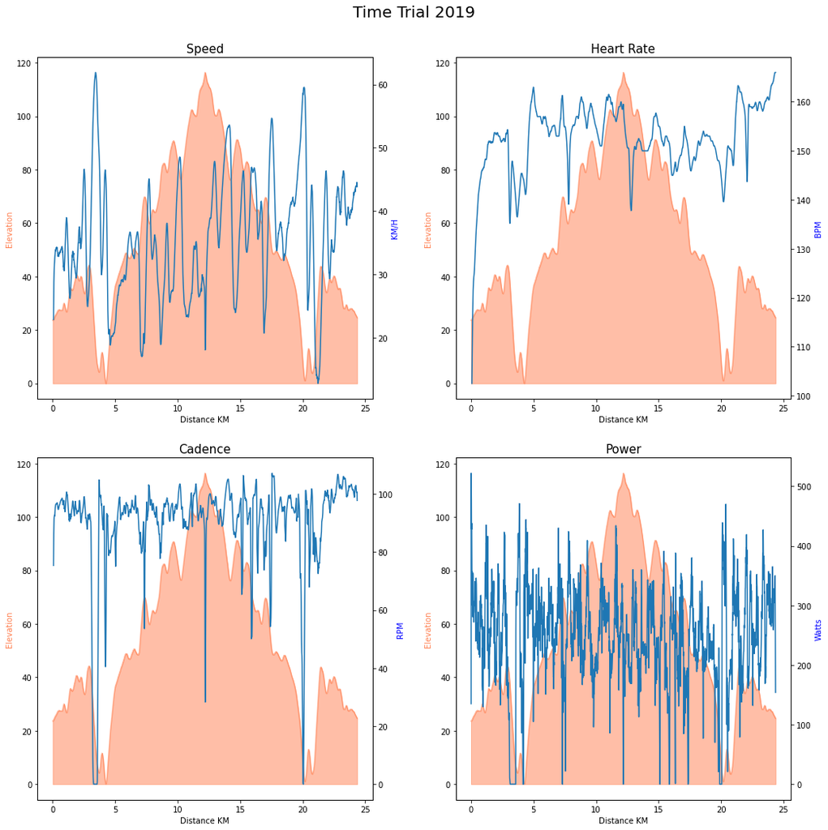

```python
fig, tt19Profile = plt.subplots(2,2,figsize=(15,15))
fig.suptitle('Time Trial 2019', size = 20)

#Speed graph
ax2 = tt19Profile[0,0].twinx()
ax2.plot(tt_2019C['distance'].cumsum(),tt_2019C['speed'])
tt19Profile[0,0].plot(tt_2019C['distance'].cumsum(),tt_2019C['elevation_idx'], alpha = 0.5, color = 'coral')
tt19Profile[0,0].fill_between(tt_2019C['distance'].cumsum(),tt_2019C['elevation_idx'], alpha = 0.5, label = '2016', color = 'coral')
tt19Profile[0,0].set_ylabel('Elevation', color = 'coral')
ax2.set_ylabel('KM/H', color = 'blue')
tt19Profile[0,0].set_title('Speed', size = 15)

#heart rate graph
ax2 = tt19Profile[0,1].twinx()
ax2.plot(tt_2019C['distance'].cumsum(),tt_2019C['hr'])
tt19Profile[0,1].plot(tt_2019C['distance'].cumsum(),tt_2019C['elevation_idx'], alpha = 0.5, color = 'coral')
tt19Profile[0,1].fill_between(tt_2019C['distance'].cumsum(),tt_2019C['elevation_idx'], alpha = 0.5, label = '2016', color = 'coral')
tt19Profile[0,1].set_ylabel('Elevation', color = 'coral')
ax2.set_ylabel('BPM', color = 'blue')
tt19Profile[0,1].set_title('Heart Rate', size = 15)

#Cadence graph
ax2 = tt19Profile[1,0].twinx()
ax2.plot(tt_2019C['distance'].cumsum(),tt_2019C['cadence'])
tt19Profile[1,0].plot(tt_2019C['distance'].cumsum(),tt_2019C['elevation_idx'], alpha = 0.5, color = 'coral')
tt19Profile[1,0].fill_between(tt_2019C['distance'].cumsum(),tt_2019C['elevation_idx'], alpha = 0.5, label = '2016', color = 'coral')
tt19Profile[1,0].set_ylabel('Elevation', color = 'coral')
ax2.set_ylabel('RPM', color = 'blue')
tt19Profile[1,0].set_title('Cadence', size = 15)

#power graph
ax2 = tt19Profile[1,1].twinx()
ax2.plot(tt_2019['distance'].cumsum(),tt_2019['power'])
tt19Profile[1,1].plot(tt_2019C['distance'].cumsum(),tt_2019C['elevation_idx'], alpha = 0.5, color = 'coral')
tt19Profile[1,1].fill_between(tt_2019C['distance'].cumsum(),tt_2019C['elevation_idx'], alpha = 0.5, label = '2016', color = 'coral')
tt19Profile[1,1].set_ylabel('Elevation', color = 'coral')
ax2.set_ylabel('Watts', color = 'blue')
tt19Profile[1,1].set_title('Power', size = 15)

for tt19Profile in tt19Profile.flat:
    tt19Profile.set(xlabel='Distance KM')

fig.tight_layout(pad = 2.5)
```

## 1.5 Comparing Ride Speed

### *Compare the range of speeds for each ride, are time trials faster than road races?*

```python
rr_2016desc = pd.DataFrame({'rr_2016':rr_2016C['speed'].describe()})
rr_2019desc = pd.DataFrame({'rr_2019':rr_2019C['speed'].describe()})
tt_2016desc = pd.DataFrame({'tt_2016':tt_2016C['speed'].describe()})
tt_2019desc = pd.DataFrame({'tt_2019':tt_2019C['speed'].describe()})
round(pd.concat([rr_2016desc,rr_2019desc,tt_2016desc,tt_2019desc], axis = 1),2)
```

|  | rr_2016 | rr_2019 | tt_2016 | tt_2019 |
| --- | --- | --- | --- | --- |
| count | 2817.00 | 5494.00 | 1532.00 | 2636.00 |
| mean | 34.96 | 33.89 | 33.64 | 33.17 |
| std | 10.37 | 8.65 | 10.72 | 9.49 |
| min | 14.98 | 10.32 | 13.04 | 12.81 |
| 25% | 26.83 | 28.36 | 25.57 | 26.64 |
| 50% | 33.49 | 33.17 | 33.12 | 33.44 |
| 75% | 42.68 | 38.53 | 41.51 | 39.38 |
| max | 66.86 | 68.62 | 64.50 | 61.89 |

## Hypothesis Test - One-way ANOVA

$H_0: \mu_{rr16} = \mu_{rr19} = \mu_{tt16} = \mu_{tt19}$

$H_1: \mu_i $ are not equal

```python
# create data frame for anova analysis
r16 = rr_2016C['speed'].reset_index(drop = True)
r19 = rr_2019C['speed'].reset_index(drop = True)
t16 = tt_2016C['speed'].reset_index(drop = True)
t19 = tt_2016C['speed'].reset_index(drop = True)
data = pd.DataFrame({'rr_2016':r16, 'rr_2019':r19, 'tt_2016':t16, 'tt_2019':t19})
df = data.melt()
df = df.dropna()
df.head(15)
```

|  | variable | value |
| --- | --- | --- |
| 5 | rr_2016 | 16.399525 |
| 6 | rr_2016 | 20.757632 |
| 7 | rr_2016 | 23.330665 |
| 8 | rr_2016 | 25.124378 |
| 9 | rr_2016 | 26.114900 |
| 10 | rr_2016 | 26.636847 |
| 11 | rr_2016 | 26.718169 |
| 12 | rr_2016 | 27.215557 |
| 13 | rr_2016 | 27.575223 |
| 14 | rr_2016 | 28.725362 |
| 15 | rr_2016 | 29.298393 |
| 16 | rr_2016 | 30.117632 |
| 17 | rr_2016 | 31.410643 |
| 18 | rr_2016 | 32.159207 |
| 19 | rr_2016 | 32.723532 |

### Anova Model

```python
model = smf.ols('value ~ variable', data = df).fit()
aov_table = anova_lm(model,typ=2)
print(aov_table)
```

```
                sum_sq       df          F        PR(>F)
variable  2.971583e+03      3.0  10.570009  6.150328e-07
Residual  1.065590e+06  11371.0        NaN           NaN
```

The pvalue is less then a significance level of 0.05. Should the model be valid there is significant evidence to reject $H_0$.

### Tukeys HSD - Multiple comparison

Multiple Comparison of Means - Tukey HSD, FWER=0.05

| group1 | group2 | meandiff | p-adj | lower | upper | reject |
| --- | --- | --- | --- | --- | --- | --- |
| rr_2016 | rr_2019 | -1.068 | 0.001 | -1.6444 | -0.4916 | True |
| rr_2016 | tt_2016 | -1.3213 | 0.001 | -2.1109 | -0.5317 | True |
| rr_2016 | tt_2019 | -1.3213 | 0.001 | -2.1109 | -0.5317 | True |
| rr_2019 | tt_2016 | -0.2533 | 0.7768 | -0.972 | 0.4653 | False |
| rr_2019 | tt_2019 | -0.2533 | 0.7768 | -0.972 | 0.4653 | False |
| tt_2016 | tt_2019 | 0.0 | 0.9 | -0.8987 | 0.8987 | False |

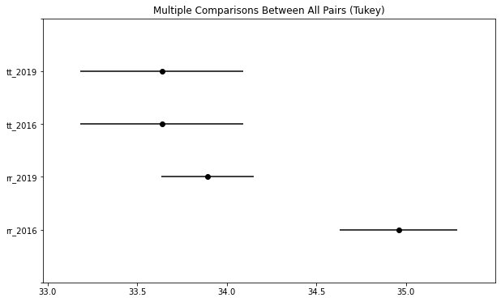

```python
mcVariable = multi.MultiComparison(df['value'], df['variable'])
tukey = mcVariable.tukeyhsd()
tukey.plot_simultaneous()
tukey.summary()
```

### Model Validation

#### Check for normality of residuals

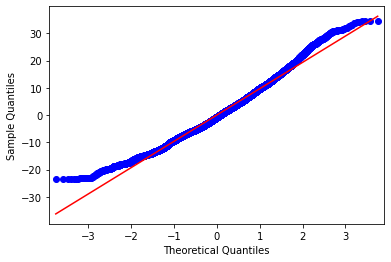

```python
residuals = model.resid
fig = sm.qqplot(residuals, line = 's')
plt.show()
```

The QQ-plot shows a slight right skew/heavy tail in the distribution of residuals however not significant. The normnality of residual assumptions holds.

#### Check for equal variance

```python
r_16 = df['value'][df['variable'] == 'rr_2016']
r_19 = df['value'][df['variable'] == 'rr_2019']
t_16 = df['value'][df['variable'] == 'tt_2016']
t_19 = df['value'][df['variable'] == 'tt_2016']
ride_std = [r_16.std(),r_19.std(),t_16.std(), t_19.std()]
stdRatio = max(ride_std)/min(ride_std)
print(f'The ratio between the Max and Min standard deviations is: {stdRatio}')
```

```
The ratio between the Max and Min standard deviations is: 1.2393567003021557
```

The ratio between the max and min standard deviation values is less then 1.5. As such the variances between groups could be equal.

## 1.6 Time Trial Comparison

### *Compare the speeds achieved in the two time trials (three years apart). As well as looking at the averages, can you see where in the ride one or the other is faster.*

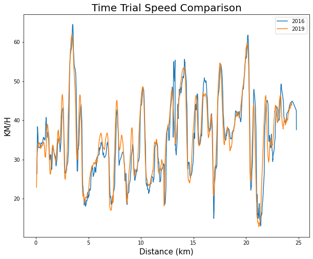

```python
plt.figure(figsize=(10,8))
plt.plot(tt_2016C['distance'].cumsum(),tt_2016C['speed'], label = '2016')
plt.plot(tt_2019C['distance'].cumsum(),tt_2019C['speed'], label = '2019')
plt.xlabel('Distance (km)', size=15)
plt.ylabel('KM/H', size=15)
plt.title("Time Trial Speed Comparison", size = 20)
plt.legend()
plt.show()
```

```python
round(pd.concat([tt_2016desc,tt_2019desc], axis = 1),2)
```

|  | tt_2016 | tt_2019 |
| --- | --- | --- |
| count | 1532.00 | 2636.00 |
| mean | 33.64 | 33.17 |
| std | 10.72 | 9.49 |
| min | 13.04 | 12.81 |
| 25% | 25.57 | 26.64 |
| 50% | 33.12 | 33.44 |
| 75% | 41.51 | 39.38 |
| max | 64.50 | 61.89 |

```python
t_16_avg = tt_2016C['speed'].mean()
t_19_avg = tt_2019C['speed'].mean()
print(f'Difference between 2016 time trial and 2019 time trial: {round(t_16_avg-t_19_avg,4)} km/h')
```

```
Difference between 2016 time trial and 2019 time trial: 0.4718 km/h
```

To identify differences in performance during specific stages of the course, the course was divided into 10 2.5km zones. A comparison between each time trial within that zone was undertaken.

```python
#2016 tt
#Create time trial dataframe
spd_16 = tt_2016C['speed'].reset_index(drop = True)
dist_16 = tt_2016C['distance'].reset_index(drop = True)
df_t16 = pd.DataFrame({'Dist.16': dist_16, 'Spd.16': spd_16, 'cum_sum':dist_16.cumsum()})

#split the ride into 10 2.5km zones
s = 2.5
e = 5
tt16_zones = []
tt16_zones.append(df_t16['Spd.16'][df_t16['cum_sum'] < 2.5])
for i in range(1,10):
    tt16_zones.append(df_t16['Spd.16'][(df_t16['cum_sum'] >=s) & (df_t16['cum_sum'] < e)])
    s= s+2.5
    e = e+2.5


#2019 tt
#Create time trial dataframe
spd_19 = tt_2019C['speed'].reset_index(drop = True)
dist_19 = tt_2019C['distance'].reset_index(drop = True)
df_t19 = pd.DataFrame({'Dist.19': dist_19, 'Spd.19': spd_19, 'cum_sum':dist_19.cumsum()})

#split the ride into 10 2.5km zones
s = 2.5
e = 5
tt19_zones = []
tt19_zones.append(df_t19['Spd.19'][df_t19['cum_sum'] < 2.5])
for i in range(1,10):
    tt19_zones.append(df_t19['Spd.19'][(df_t19['cum_sum'] >=s) & (df_t19['cum_sum'] < e)])
    s= s+2.5
    e = e+2.5
```

```python
labels = ['Z1','Z2','Z3','Z4','Z5','Z6','Z7','Z8','Z9','Z10']

tt16_zones_avg = pd.Series([round(x.mean(),2) for x in tt16_zones])
tt19_zones_avg = pd.Series([round(x.mean(),2) for x in tt19_zones])
difference = tt16_zones_avg - tt19_zones_avg
df = pd.DataFrame({'zone':labels, 'tt16_avg':tt16_zones_avg, 'tt19_avg':tt19_zones_avg, 'diff':difference})
df
```

|  | zone | tt16_avg | tt19_avg | diff |
| --- | --- | --- | --- | --- |
| 0 | Z1 | 33.47 | 33.13 | 0.34 |
| 1 | Z2 | 33.20 | 32.59 | 0.61 |
| 2 | Z3 | 25.96 | 27.78 | -1.82 |
| 3 | Z4 | 29.37 | 30.84 | -1.47 |
| 4 | Z5 | 29.66 | 29.64 | 0.02 |
| 5 | Z6 | 40.65 | 38.35 | 2.30 |
| 6 | Z7 | 38.23 | 37.55 | 0.68 |
| 7 | Z8 | 42.84 | 40.58 | 2.26 |
| 8 | Z9 | 29.54 | 28.40 | 1.14 |
| 9 | Z10 | 41.45 | 41.15 | 0.30 |

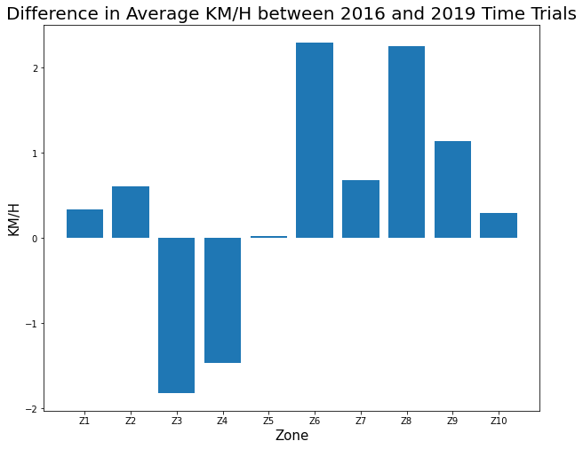

```python
plt.figure(figsize=(10,8))
plt.bar(df['zone'], df['diff'])
plt.xlabel('Zone', size=15)
plt.ylabel('KM/H', size=15)
plt.title("Difference in Average KM/H between 2016 and 2019 Time Trials", size = 20)
plt.show()
```

### Conclusion

The largest differences between the average speed per zone was observed in zones 3,4,6,8 and 9. Zones 3 and 4 showed a faster average speed during the 2019 time trial. Zones 6,8 and 9 showed a faster average speed during the 2016 time trial.

## 1.7 Climbing/Descending Speeds

_From the elevation_gain field you can see whether the rider is climbing , descending or on the flat. Use this to calculate the average speeds in those three cases (climbing, flat or descending). Note that flat might not be zero elevation*gain but might allow for slight climbs and falls.*

The flat were defined as a gradient $> -2.5$% and $< 2.5$%

Climbs were defined as gradient $>= 2.5$%

Descents were defined as gradient $<= -2.5$%

```python
#road race 2016
rr_2016_flat = rr_2016[((rr_2016['elevation_gain'] / (rr_2016['distance']*1000)) > -0.025) & ((rr_2016['elevation_gain'] / (rr_2016['distance']*1000)) < 0.025)]
rr_2016_clim = rr_2016[((rr_2016['elevation_gain'] / (rr_2016['distance']*1000)) >= 0.025)]
rr_2016_desc = rr_2016[((rr_2016['elevation_gain'] / (rr_2016['distance']*1000)) <= -0.025)]

#road race 2019
rr_2019_flat = rr_2019[((rr_2019['elevation_gain'] / (rr_2019['distance']*1000)) > -0.025) & ((rr_2019['elevation_gain'] / (rr_2019['distance']*1000)) < 0.025)]
rr_2019_clim = rr_2019[((rr_2019['elevation_gain'] / (rr_2019['distance']*1000)) >= 0.025)]
rr_2019_desc = rr_2019[((rr_2019['elevation_gain'] / (rr_2019['distance']*1000)) <= -0.025)]

#time trial 2016
tt_2016_flat = tt_2016[((tt_2016['elevation_gain'] / (tt_2016['distance']*1000)) > -0.025) & ((tt_2016['elevation_gain'] / (tt_2016['distance']*1000)) < 0.025)]
tt_2016_clim = tt_2016[((tt_2016['elevation_gain'] / (tt_2016['distance']*1000)) >= 0.025)]
tt_2016_desc = tt_2016[((tt_2016['elevation_gain'] / (tt_2016['distance']*1000)) <= -0.025)]

#time trial 2019
tt_2019_flat = tt_2019[((tt_2019['elevation_gain'] / (tt_2019['distance']*1000)) > -0.025) & ((tt_2019['elevation_gain'] / (tt_2019['distance']*1000)) < 0.025)]
tt_2019_clim = tt_2019[((tt_2019['elevation_gain'] / (tt_2019['distance']*1000)) >= 0.025)]
tt_2019_desc = tt_2019[((tt_2019['elevation_gain'] / (tt_2019['distance']*1000)) <= -0.025)]

flat = pd.Series([rr_2016_flat['speed'].mean(), rr_2019_flat['speed'].mean(), tt_2016_flat['speed'].mean(), tt_2019_flat['speed'].mean()], index = raceType)
clim = pd.Series([rr_2016_clim['speed'].mean(), rr_2019_clim['speed'].mean(), tt_2016_clim['speed'].mean(), tt_2019_clim['speed'].mean()], index = raceType)
desc = pd.Series([rr_2016_desc['speed'].mean(), rr_2019_desc['speed'].mean(), tt_2016_desc['speed'].mean(), tt_2019_desc['speed'].mean()], index = raceType)


gradientSummary = pd.DataFrame({'Flat':flat, 'Climb': clim, 'Descent': desc}, index = raceType)
gradientSummary.round(2)
```

|  | Flat | Climb | Descent |
| --- | --- | --- | --- |
| Road Race 2016 | 34.40 | 26.08 | 46.26 |
| Road Race 2019 | 34.78 | 26.32 | 44.43 |
| Time Trial 2016 | 33.99 | 24.48 | 45.42 |
| Time Trial 2019 | 35.17 | 23.19 | 47.00 |

## 1.9 Challenge: Gear Usage

A modern race bike has up to 22 different gears with two chainrings on the front (attached to the pedals) and 10 or 11 at the back (attached to the wheel). The ratio of the number of teeth on the front and rear cogs determines the distance travelled with one revolution of the pedals (often called **development**, measured in metres). Low development is good for climbing hills while high development is for going fast downhill or in the final sprint.

We have a measure of the number of rotations of the pedals per minute (**cadence**) and a measure of **speed**. Using these two variables we should be able to derive a measure of **development** which would effectivly tell us which gear the rider was using at the time. Development will normally range between **2m** and **10m**. Due to errors in GPS and cadence measurements you will see many points outside this range and you should just discard them as outliers.

Write code to calculate **development** in *meters* for each row in a ride. Plot the result in a *histogram* and compare the plots for the four rides. Comment on what you observe in the histograms.

```python
#road race 2016 development
rr_2016C['Development'] = ((rr_2016C['speed']*50/3)/rr_2016C['cadence'])
#road race 2019 development
rr_2019C['Development'] = ((rr_2019C['speed']*50/3)/rr_2019C['cadence'])
#time trial 2016 development
tt_2016C['Development'] = ((tt_2016C['speed']*50/3)/tt_2016C['cadence'])
#time trial 2019 development
tt_2019C['Development'] = ((tt_2019C['speed']*50/3)/tt_2019C['cadence'])

#dropping outliers
races = [rr_2016C, rr_2019C, tt_2016C, tt_2019C]
for i in races:
    i = i.drop(i[(i['Development']<2)|(i['Development']>10)].index,inplace=True)
```

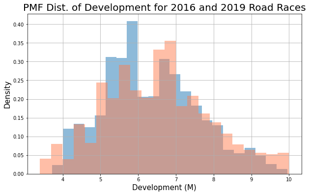

```python
plt.figure(figsize=(10,6))
rr_2016C['Development'].hist(histtype = 'stepfilled', density = True, bins = 22, alpha = 0.5)
rr_2019C['Development'].hist(histtype = 'stepfilled', density = True, bins = 22, color = 'coral', alpha = 0.5)
plt.title('PMF Dist. of Development for 2016 and 2019 Road Races', size = 20)
plt.xlabel('Development (M)', size = 15)
plt.ylabel('Density', size = 15)
plt.show()
```

The distribution of development showed larger gears were selected with a slightly higher frequency during the 2019 road race then compared to the 2016 road race.

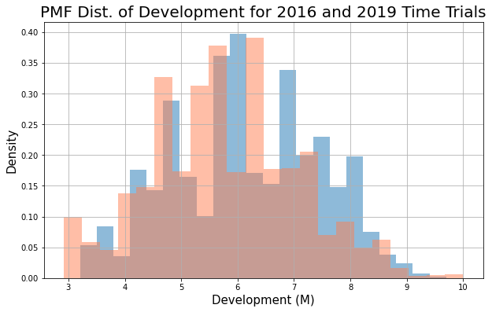

```python
plt.figure(figsize=(10,6))
tt_2016C['Development'].hist(histtype = 'stepfilled', density = True, bins = 22, alpha = 0.5)
tt_2019C['Development'].hist(histtype = 'stepfilled', density = True, bins = 22, color = 'coral', alpha = 0.5)
plt.title('PMF Dist. of Development for 2016 and 2019 Time Trials', size = 20)
plt.xlabel('Development (M)', size = 15)
plt.ylabel('Density', size = 15)
plt.show()
```

The distribution of development showed smaller gears were selected with a slightly higher frequency during the 2019 time trial compared to the 2016 time trial.